# MAchine Learning Course Final Project

Peihuan Meng

9/25/2020

## Synopsis

Using devices such as Jawbone Up, Nike FuelBand, and Fitbit, it is now possible to collect a large amount of data about personal activity relatively inexpensively. These type of devices are part of the quantified self movement – a group of enthusiasts who take measurements about themselves regularly to improve their health, to find patterns in their behavior, or because they are tech geeks. One thing that people regularly do is quantify how much of a particular activity they do, but they rarely quantify how well they do it.

The data used in this project is collected from accelerometers on the belt, forearm, arm, and dumbell of 6 participants. They were asked to perform barbell lifts correctly and incorrectly in 5 different ways.

The goal of this project is to predict the manner in which they did the exercise. This is the **classe** variable in the training set. We cab use any of the other variables to predict with. We are asked to create a report describing how we built our model, how we used cross validation, what we think the expected out of sample error is, and why we made the choices we did. At the end, we are asked to use our prediction model to predict 20 different test cases.

More information about the data is available from the website here: http://groupware.les.inf.puc-rio.br/har (see the section on the Weight Lifting Exercise Dataset).

## Exploratory Analysis & Data Clean-up

The data set has 19622 observations and 160 variables (including the outcome variable **classe**).

```r
install.packages("corrplot", repos = "http://cran.cnr.berkeley.edu/")
install.packages("scales", repos = "http://cran.cnr.berkeley.edu/")
library(caret)
library(dplyr)
library(corrplot)
library(rattle)
library(scales)
```

```r
original <- read.csv(url("https://d396qusza40orc.cloudfront.net/predmachlearn/pml-training.csv"), na.strings=c("NA","#DIV/0!", ""), colClasses = c("classe" = "factor"))
validating <- read.csv(url("https://d396qusza40orc.cloudfront.net/predmachlearn/pml-testing.csv"), na.strings=c("NA","#DIV/0!", ""))
dim(original)
```

```
## [1] 19622   160
```

```r
dim(validating)
```

```
## [1]  20 160
```

A closer look reveals there are a good number of varialbes with a very high percentage of NAs.

```r
str(original)
```

```
## 'data.frame':    19622 obs. of  160 variables:
##  $ X                       : int  1 2 3 4 5 6 7 8 9 10 ...
##  $ user_name               : chr  "carlitos" "carlitos" "carlitos" "carlitos" ...
##  $ raw_timestamp_part_1    : int  1323084231 1323084231 1323084231 1323084232 1323084232 1323084232 1323084232 1323084232 1323084232 1323084232 ...
##  $ raw_timestamp_part_2    : int  788290 808298 820366 120339 196328 304277 368296 440390 484323 484434 ...
##  $ cvtd_timestamp          : chr  "05/12/2011 11:23" "05/12/2011 11:23" "05/12/2011 11:23" "05/12/2011 11:23" ...
##  $ new_window              : chr  "no" "no" "no" "no" ...
##  $ num_window              : int  11 11 11 12 12 12 12 12 12 12 ...
##  $ roll_belt               : num  1.41 1.41 1.42 1.48 1.48 1.45 1.42 1.42 1.43 1.45 ...
##  $ pitch_belt              : num  8.07 8.07 8.07 8.05 8.07 8.06 8.09 8.13 8.16 8.17 ...
##  $ yaw_belt                : num  -94.4 -94.4 -94.4 -94.4 -94.4 -94.4 -94.4 -94.4 -94.4 -94.4 ...
##  $ total_accel_belt        : int  3 3 3 3 3 3 3 3 3 3 ...
##  $ kurtosis_roll_belt      : num  NA NA NA NA NA NA NA NA NA NA ...
##  $ kurtosis_picth_belt     : num  NA NA NA NA NA NA NA NA NA NA ...
##  $ kurtosis_yaw_belt       : logi  NA NA NA NA NA NA ...
```

[output cut: 86 more lines]

We selected those variables whose NA’s are less then 50%. Also we notice the first 7 columns are sequence infomation which does not contribute to the outcome. So we exclude them as well from the prediction.

Also, there are no NAs left, so no need for imputing pre-processing.

```r
threshold <-  nrow(original) / 2
selectPredictor1 <- original[, colSums(is.na(original)) < threshold]
dim(selectPredictor1)
```

```
## [1] 19622    60
```

```r
selectPredictor2 <- selectPredictor1[, -c(1:7)]
dim(selectPredictor2)
```

```
## [1] 19622    53
```

```r
any(is.na(selectPredictor2))
```

```
## [1] FALSE
```

We now are left with a data set with 53 variables for further analysis.

## Coorelation Analysis

Next we run coorelation analysis between every 2 varialbes excluding the outcome variable to get a sense how coorelated the predictors are.

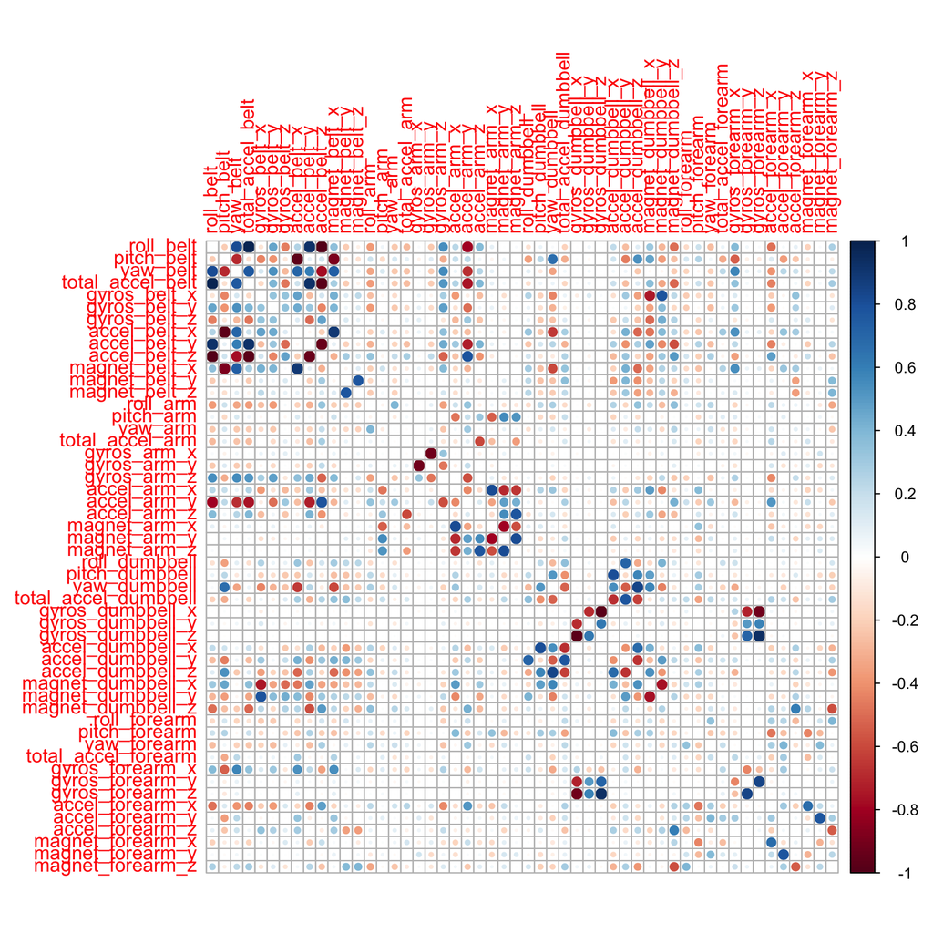

```r
corr <- cor(selectPredictor2[, -53])
diag(corr) <- 0
corrplot(corr)
```

The plot indicates quite a number of highly coorelated pairs (dark blue and dark red spots). We print out those with the absolute value of coorelation greater than 0.9 below.

```r
which(corr > 0.9 | corr < -0.9, arr.ind = T)
```

```
##                  row col
## total_accel_belt   4   1
## accel_belt_y       9   1
## accel_belt_z      10   1
## accel_belt_x       8   2
## roll_belt          1   4
## accel_belt_y       9   4
## accel_belt_z      10   4
## pitch_belt         2   8
## roll_belt          1   9
## total_accel_belt   4   9
## accel_belt_z      10   9
## roll_belt          1  10
## total_accel_belt   4  10
## accel_belt_y       9  10
## gyros_arm_y       19  18
## gyros_arm_x       18  19
## gyros_dumbbell_z  33  31
## gyros_forearm_z   46  31
## gyros_dumbbell_x  31  33
## gyros_forearm_z   46  33
## gyros_dumbbell_x  31  46
## gyros_dumbbell_z  33  46
```

In particular, we take a look at roll_belt, accel_belt_z to get a sense of the relationship bwtween the 2.

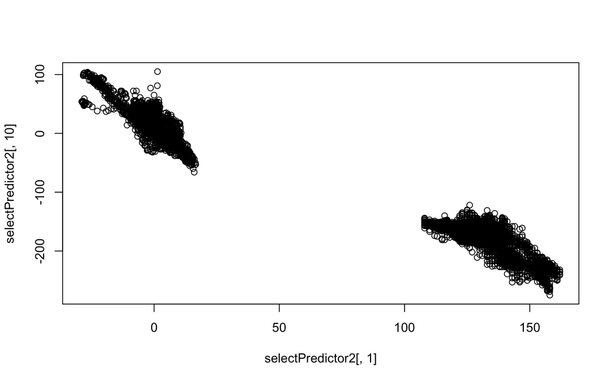

```r
plot(selectPredictor2[,1],selectPredictor2[,10])
```

## Data Slicing

We slice the data into 75% for the training set and 25% for testing.

```r
inTrain <- createDataPartition(y = selectPredictor2$classe, p=0.75, list=FALSE)
training <- selectPredictor2[inTrain,]
testing <- selectPredictor2[-inTrain,]
```

## Pre-processing

```r
set.seed(2121)
preProcess(training[, -53], method="pca", thresh=0.95)
```

```
## Created from 14718 samples and 52 variables
##
## Pre-processing:
##   - centered (52)
##   - ignored (0)
##   - principal component signal extraction (52)
##   - scaled (52)
##
## PCA needed 25 components to capture 95 percent of the variance
```

```r
preProcessed <- preProcess(training[, -53], method="pca", thresh=0.80)
preProcessed
```

```
## Created from 14718 samples and 52 variables
##
## Pre-processing:
##   - centered (52)
##   - ignored (0)
##   - principal component signal extraction (52)
##   - scaled (52)
##
## PCA needed 12 components to capture 80 percent of the variance
```

```r
trainTransformed <- predict(preProcessed, training)
testTransformed <- predict(preProcessed, testing)
validateTransformed <- predict(preProcessed, validating)
```

## Fit a model with Gradient Boosting Machine (GBM) Algorithm

```r
set.seed(2324)
gbmFit <- train(classe ~ ., data = trainTransformed, method = "gbm", trControl = trainControl(method="cv", number=10, allowParallel=TRUE), verbose = FALSE)
gbmPredicted <- predict(gbmFit, testTransformed)
gbmMatrix <- confusionMatrix(gbmPredicted, testTransformed$classe)
gbmMatrix
```

```
## Confusion Matrix and Statistics
##
##           Reference
## Prediction    A    B    C    D    E
##          A 1172  105  108   58   39
##          B   45  670   63   41   68
##          C   77  101  635   85   86
##          D   81   43   28  594   45
##          E   20   30   21   26  663
##
## Overall Statistics
##
##                Accuracy : 0.7614
##                  95% CI : (0.7492, 0.7733)
##     No Information Rate : 0.2845
##     P-Value [Acc > NIR] : < 2.2e-16
##
##                   Kappa : 0.6977
##
##  Mcnemar's Test P-Value : < 2.2e-16
##
## Statistics by Class:
##
##                      Class: A Class: B Class: C Class: D Class: E
## Sensitivity            0.8401   0.7060   0.7427   0.7388   0.7358
## Specificity            0.9117   0.9451   0.9138   0.9520   0.9758
## Pos Pred Value         0.7908   0.7554   0.6453   0.7509   0.8724
## Neg Pred Value         0.9348   0.9305   0.9439   0.9489   0.9426
## Prevalence             0.2845   0.1935   0.1743   0.1639   0.1837
## Detection Rate         0.2390   0.1366   0.1295   0.1211   0.1352
## Detection Prevalence   0.3022   0.1809   0.2007   0.1613   0.1550
## Balanced Accuracy      0.8759   0.8256   0.8282   0.8454   0.8558
```

With Gradient Boosting Machine, we achieve 76% accuracy.

## Fit a model with Random Forest Algorithm

```r
set.seed(5662)
rfFit <- train(classe ~ ., data = trainTransformed, method = "rf", trControl = trainControl(method="cv", number=10, allowParallel=TRUE), verbose = FALSE)
rfPredicted <- predict(rfFit, testTransformed)
rfMatrix <- confusionMatrix(rfPredicted, testTransformed$classe)
rfMatrix
```

```
## Confusion Matrix and Statistics
##
##           Reference
## Prediction    A    B    C    D    E
##          A 1379   20   11   14    1
##          B    3  910   12    4    6
##          C    4   17  822   41    6
##          D    6    1    8  742    9
##          E    3    1    2    3  879
##
## Overall Statistics
##
##                Accuracy : 0.9649
##                  95% CI : (0.9594, 0.9699)
##     No Information Rate : 0.2845
##     P-Value [Acc > NIR] : < 2.2e-16
##
##                   Kappa : 0.9556
##
##  Mcnemar's Test P-Value : 6.038e-08
##
## Statistics by Class:
##
##                      Class: A Class: B Class: C Class: D Class: E
## Sensitivity            0.9885   0.9589   0.9614   0.9229   0.9756
## Specificity            0.9869   0.9937   0.9832   0.9941   0.9978
## Pos Pred Value         0.9677   0.9733   0.9236   0.9687   0.9899
## Neg Pred Value         0.9954   0.9902   0.9918   0.9850   0.9945
## Prevalence             0.2845   0.1935   0.1743   0.1639   0.1837
## Detection Rate         0.2812   0.1856   0.1676   0.1513   0.1792
## Detection Prevalence   0.2906   0.1907   0.1815   0.1562   0.1811
## Balanced Accuracy      0.9877   0.9763   0.9723   0.9585   0.9867
```

With Random Forest, we achieve 96% accuracy, which is 20% better than GBM.

## Prediction with Random Forest

```r
predicted <- predict(rfFit, validateTransformed)
predicted
```

```
##  [1] B A A A A E D B A A B C B A E E A B B B
## Levels: A B C D E
```